# Exam – R part

Stéphanie Allassonnière, Geneviève Robin, Elodie Vernet and Zoltán Szabó

November 13 2018

A cholesterol level above $240mg/dl$ of blood is a risk factor for heart disease. A lab has changed the flavour of a medicine used to diminish the cholesterol level. A study to test the effectiveness of the new version was conducted. Fifty people with cholesterol level between $240$ and $260$ were assigned at random to each of two treatments groups. Group A received the standard medicine and group B received the new medicine. The observed cholesterol level after the treatment are

- for group A: 275, 255, 247, 206, 245, 196, 229, 218, 238, 224, 217, 205, 252, 194, 203, 192, 232, 239, 223, 239, 217, 241, 230, 216, 227,
- for group B: 238, 216, 214, 247, 250, 223, 207, 254, 228, 219, 223, 247, 228, 207, 204, 225, 201, 253, 216, 223, 219, 224, 225, 228, 225.

The cholesterol levels of group A and B are independent and i.i.d. Gaussian random variables distributed as $\mathcal{N}(m_A,\sigma_A)$ and $\mathcal{N}(m_B,\sigma_B)$ respectively.

We don’t expect to see a difference between these two medicines. We assume that $\sigma:=\sigma_A=\sigma_B$ and we want to test $H_0: ~ m_A=m_B$ against $H_1: ~ m_A \neq m_B$.

1. Create a dataframe which contains the data.

```r
group_A <- c(275, 255, 247, 206, 245, 196, 229, 218, 238, 224, 217, 205, 252, 194, 203, 192, 232, 239, 223, 239, 217, 241, 230, 216, 227)
group_B <- c(238, 216, 214, 247, 250, 223, 207, 254, 228, 219, 223, 247, 228, 207, 204, 225, 201, 253, 216, 223, 219, 224, 225, 228, 225)
AB <- cbind(group_A, group_B)
dataframe_AB <- as.data.frame(AB)
dataframe_AB
```

| group_A | group_B |
| --- | --- |
| 275 | 238 |
| 255 | 216 |
| 247 | 214 |
| 206 | 247 |
| 245 | 250 |
| 196 | 223 |
| 229 | 207 |
| 218 | 254 |
| 238 | 228 |
| 224 | 219 |

[output cut: 15 more lines]

2. Check visually that the distribution of the cholesterol levels of group A and B can be modeled as Gaussian.

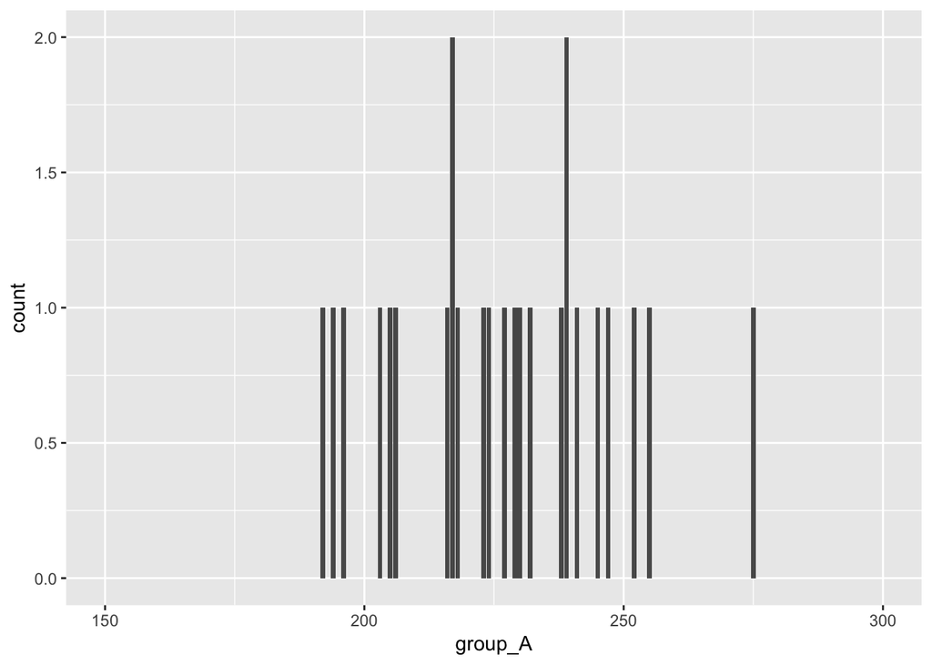

```r
ggplot(dataframe_AB) + aes(x = group_A) + xlim(150, 300) + geom_bar()
```

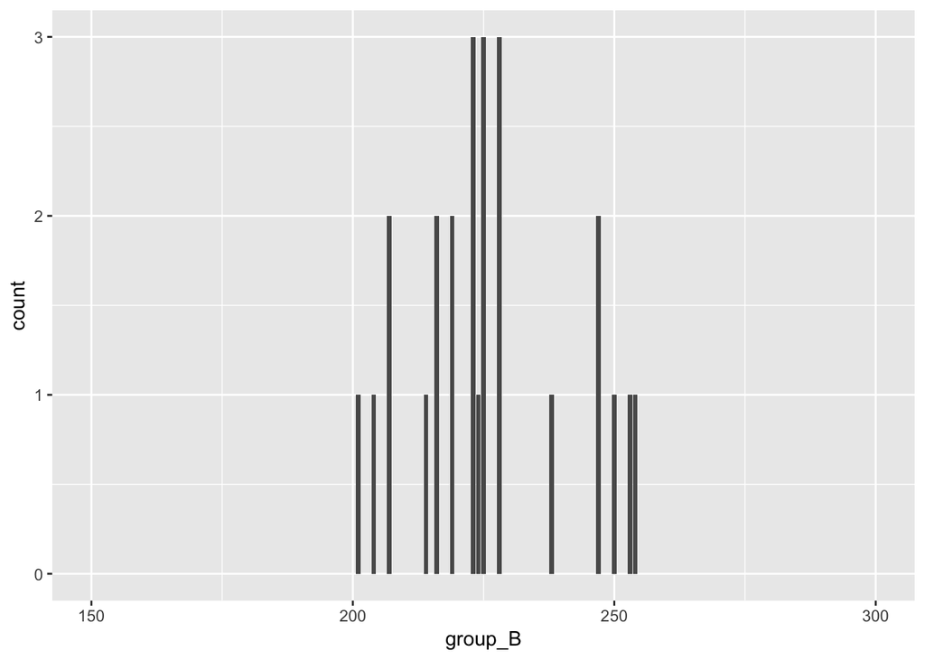

```r
ggplot(dataframe_AB) + aes(x = group_B) + xlim(150, 300) + geom_bar()
```

```r
# Visually, we can assume that they can be modeled as Gaussion in view of these histograms
```

3. Propose a test at level $\alpha$ for $H_0: ~ m_A=m_B$ against $H_0: ~ m_A \neq m_B$. Give the statistical model, the statistic that you use, its distribution under $H_0$, the test function and its p-value. Hint: You could look at PC8 as a source of inspiration.

```r
# We call xi the ith observation in group A and yi the ith observation in group B, for i <= 25. We assume that (x1,...x25) and (y1,...y25) are realizations of (X1,...X25) and (Y1,...Y25) where (X1,...X25) and (Y1...Y25) are two independent random vectors, Xi are iid N(m1, sigma^2) and Yi are iid N(m2, sigma^2). Then (X1,...X25,Y1...Y25) is a Gaussian vector with mean vector (m1,...m1, m2,...m2) and covariance matrix sigma^2*I where I is the identity matrix of size 50*50.

# Therefore, the statistical model is (R^50, B(R^50), (N((m1,...m1,m2,...m2), sigma^2*I), m1 € R, m2 € R, sigma >0)).

# I will use the test statistic T = sqrt(n)(1/n*sum(Xi) - 1/n*sum(Yi))/sqrt(2*sigma^2), that follows a T(48) under H0.

# Under Ho, it should be near 0, and under H1, T in absolute value should become higher than a critical value c(alpha). The indicator function with parameter (p(abs(z) > c(alpha))) is the test function.
# c(alpha) = t(1-alpha/2) for for z a realization of our test function T.

# The p-value is p(abs(T)>T_obs) = 2 * p(T > T_obs) = 2(1 - p(T <= T_obs)).
```

4. Write an R function **test** with inputs $x=(x_1,\ldots, x_n)$, $y=(y_1,\ldots, y_n)$, $\alpha$ and output of a vector of size five containing the empirical mean of $x$, the empirical mean of $y$, the observed value of the statistics, the critical value of the rejection region, the observed value of the test function ($0$ or $1$) and the p-value.

```r
test <- function(x , y , alpha){
  z <- c(0,0,0,0,0,0)
  z[1] <- mean(x)
  z[2] <- mean(y)
  z[3] <- sqrt(25)* (mean(x) - mean(y)) / (sqrt(sd(x)^2 + sd(y)^2))
  z[4] <- qt(1-alpha/2,df=48)
  z[5] <- abs(z[3]) > z[4]
  z[6] <- 2*(1-pt(z[3], df = 48))
return(z)}
```

5. Check that significance level of your test through $I=1000$ simulations when $n=25$, $\alpha=0.05$, $m_A=m_B=220$ and $\sigma=20$.

```r
mA <- 220
mB <- 220
alpha <- 0.05
n <- 25
sigma <- 20
df <- 2 * (n-1)

samples_A <- lapply(1:1e3, function(i) rnorm(n, mA, sigma))
samples_B <- lapply(1:1e3, function(i) rnorm(n, mB, sigma))
tests <- mapply(test,samples_A,samples_B, alpha)
test_functions <- tests[5,]
sum(test_functions)/1e3
```

[output not shown]

6. Approximate the probability that your test appropriately rejects $H_0$ when $n=25$, $\alpha=0.05$, $m_A=220$, $m_B=230$ and $\sigma=20$ using the Monte-Carlo method (using $I=1000$ simulations).

```r
mA <- 220
mB <- 230
alpha <- 0.05
n <- 25
sigma <- 20
df <- 2 * (n-1)

samples_A <- lapply(1:1e3, function(i) rnorm(n, mA, sigma))
samples_B <- lapply(1:1e3, function(i) rnorm(n, mB, sigma))
tests <- mapply(test,samples_A,samples_B, alpha)
test_functions <- tests[5,]
sum(test_functions)/1e3
```

```
## [1] 0.427
```

```r
# Here H0 is false so our test should reject it (mA is different from mB). However, our test only rejects it (appropriately) in about 40% of the cases. This might be because 220 and 230 are not so far.
```

7. Apply your test to the cholesterol data.

```r
test(group_A, group_B, 0.05)
```

```
## [1] 226.4000000 225.7600000   0.1250878   2.0106348   0.0000000   0.9009764
```

```r
# The empirical mean of sample_A is 226.4.
# The empirical mean of sample_B is 225.76.
# The observed value or our test statistic is 0.1250878.
# The critical value of our rejection region is 2.0106348.
# Our test function takes 0 as value, which means we do not reject H0 in this case.
# The P-value of our test is 0.9009764, which is very big : there is very little suspicion against H0.
```